# title

### 4.1.3 statistical tests

Combining statistical tests like **correlation** with the respective plot:

```r
cor(dat$mean_stf, dat$mean_imEnrich, use = "complete")
```

```
## [1] 0.4120765
```

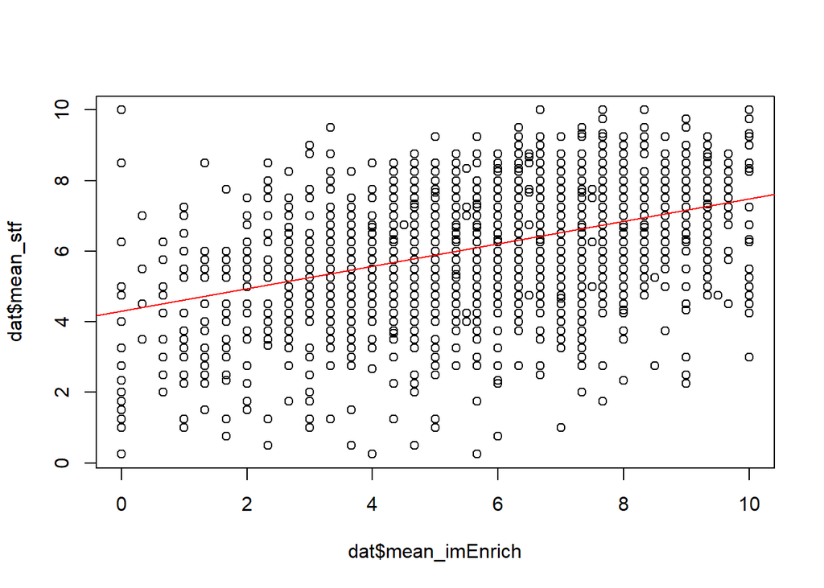

```r
plot(dat$mean_stf ~ dat$mean_imEnrich)
lm <- lm(formula = mean_stf ~ mean_imEnrich, data = dat)
abline(lm, col = "red")
```

Combining statistical tests like **t.test** with the respective plot:

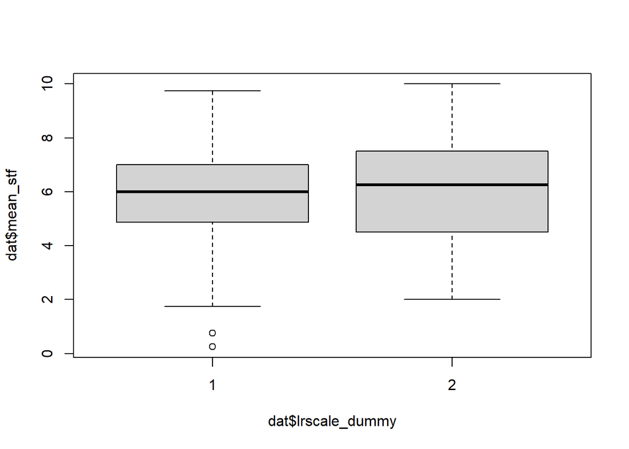

```r
dat$lrscale_dummy[dat$lrscale_dummy == 0] <- NA
boxplot(dat$mean_stf ~ dat$lrscale_dummy)
```

```r
t.test(dat$mean_stf ~ dat$lrscale_dummy)
```

```
##
##  Welch Two Sample t-test
##
## data:  dat$mean_stf by dat$lrscale_dummy
## t = -0.95096, df = 255.16, p-value = 0.3425
## alternative hypothesis: true difference in means is not equal to 0
## 95 percent confidence interval:
##  -0.6130278  0.2137742
## sample estimates:
## mean in group 1 mean in group 2
##        5.903040        6.102667
```

Based on the dichotomized `lrscale` variable compute two **multiple linear regressions**:

```r
# get subsets of data
dat_upper <- dat %>%
  filter(dat$lrscale_scaled > mean_upper)
dat_lower <- dat %>%
  filter(dat$lrscale_scaled < mean_lower)
# compute linear models
lm_upper <- lm(formula = mean_imEnrich ~ mean_stf + happy + agea + gndr, data = dat_upper)
lm_lower <- lm(formula = mean_imEnrich ~ mean_stf + happy + agea + gndr, data = dat_lower)
summary(lm_upper)
```

```
##
## Call:
## lm(formula = mean_imEnrich ~ mean_stf + happy + agea + gndr,
##     data = dat_upper)
##
## Residuals:
##     Min      1Q  Median      3Q     Max
## -4.6841 -1.6584  0.1314  1.4570  6.1086
##
## Coefficients:
##              Estimate Std. Error t value Pr(>|t|)
## (Intercept) -1.062783   1.147169  -0.926    0.356
## mean_stf     0.785843   0.119860   6.556 1.46e-09 ***
## happy       -0.042468   0.109371  -0.388    0.698
## agea         0.007579   0.010280   0.737    0.462
## gndr         0.642806   0.394721   1.629    0.106
## ---
## Signif. codes:  0 '***' 0.001 '**' 0.01 '*' 0.05 '.' 0.1 ' ' 1
##
## Residual standard error: 2.153 on 120 degrees of freedom
## Multiple R-squared:  0.3193, Adjusted R-squared:  0.2966
## F-statistic: 14.07 on 4 and 120 DF,  p-value: 1.916e-09
```

```r
summary(lm_lower)
```

```
##
## Call:
## lm(formula = mean_imEnrich ~ mean_stf + happy + agea + gndr,
##     data = dat_lower)
##
## Residuals:
##     Min      1Q  Median      3Q     Max
## -6.7190 -1.1833  0.2207  1.3061  4.0256
##
## Coefficients:
##              Estimate Std. Error t value Pr(>|t|)
## (Intercept)  5.366528   0.963260   5.571 1.11e-07 ***
## mean_stf     0.150047   0.113644   1.320    0.189
## happy        0.064136   0.099303   0.646    0.519
## agea        -0.005381   0.007890  -0.682    0.496
## gndr        -0.101868   0.330032  -0.309    0.758
## ---
## Signif. codes:  0 '***' 0.001 '**' 0.01 '*' 0.05 '.' 0.1 ' ' 1
##
## Residual standard error: 2.052 on 153 degrees of freedom
##   (1 observation deleted due to missingness)
## Multiple R-squared:  0.02873,    Adjusted R-squared:  0.003335
## F-statistic: 1.131 on 4 and 153 DF,  p-value: 0.3439
```

Again we can use the **stargazer** package, which identifies `lm_upper` for example as an lm-object in R and creates a wonderfull table for the model results:

```r
stargazer(lm_upper, type = "html")
```

|  | *Dependent variable:* |
| --- | --- |
|  | mean_imEnrich |
| mean_stf | 0.786*** |
|  | (0.120) |
| happy | -0.042 |
|  | (0.109) |
| agea | 0.008 |
|  | (0.010) |
| gndr | 0.643 |
|  | (0.395) |
| Constant | -1.063 |
|  | (1.147) |
| Observations | 125 |
| R<sup>2</sup> | 0.319 |
| Adjusted R<sup>2</sup> | 0.297 |
| Residual Std. Error | 2.153 (df = 120) |
| F Statistic | 14.071*** (df = 4; 120) |
| *Note:* | p<0.1; p<0.05; p<0.01 |

```r
stargazer(lm_lower, type = "html")
```

|  | *Dependent variable:* |
| --- | --- |
|  | mean_imEnrich |
| mean_stf | 0.150 |
|  | (0.114) |
| happy | 0.064 |
|  | (0.099) |
| agea | -0.005 |
|  | (0.008) |
| gndr | -0.102 |
|  | (0.330) |
| Constant | 5.367*** |
|  | (0.963) |
| Observations | 158 |
| R<sup>2</sup> | 0.029 |
| Adjusted R<sup>2</sup> | 0.003 |
| Residual Std. Error | 2.052 (df = 153) |
| F Statistic | 1.131 (df = 4; 153) |
| *Note:* | p<0.1; p<0.05; p<0.01 |

investigate finding:

```r
## right orientation
```

```
#> happy
```

```r
cor(dat_upper$happy, dat_upper$mean_imEnrich, use = "complete")
```

```
## [1] 0.2163281
```

```
#> with political system
```

```r
cor(dat_upper$mean_stf, dat_upper$mean_imEnrich, use = "complete")
```

```
## [1] 0.5476751
```

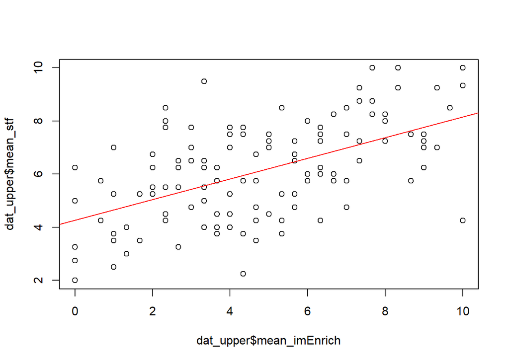

```r
plot(dat_upper$mean_stf ~ dat_upper$mean_imEnrich)
lm <- lm(formula = mean_stf ~ mean_imEnrich, data = dat_upper)
abline(lm, col = "red")
```

```r
## left orientation
```

```
#> happy
```

```r
cor(dat_lower$happy, dat_lower$mean_imEnrich, use = "complete")
```

```
## [1] 0.1172531
```

```
#> with political system
```

```r
cor(dat_lower$mean_stf, dat_lower$mean_imEnrich, use = "complete")
```

```
## [1] 0.1349888
```

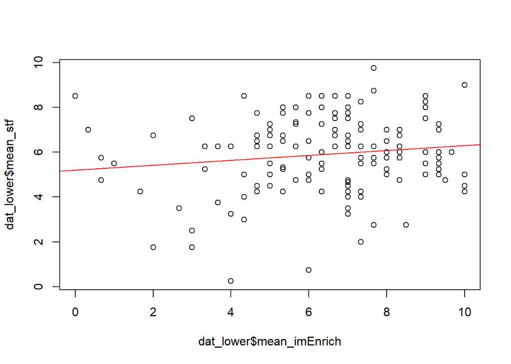

```r
plot(dat_lower$mean_stf ~ dat_lower$mean_imEnrich)
lm <- lm(formula = mean_stf ~ mean_imEnrich, data = dat_lower)
abline(lm, col = "red")
```

## 4.3 data analysis additional

# 5 Discussion

# 6 Appendix

# References

Leeuw, Edith, Joop Hox, and Don Dillman. 2012. *International Handbook of Survey Methodology*. Routledge.

Rutkowski, Leslie, Matthias Davier, and David Rutkowski. 2013. *Handbook of International Large-Scale Assessment: Background, Technical Issues, and Methods of Data Analysis*. CRC Press.

[^1]: see https://www.dw.com/en/migration-mother-of-all-political-problems-says-german-interior-minister-horst-seehofer/a-45378092, retrieved 9 February 2022